# $k$-NEAREST NEIGHBOR REGRESSION EXERCISE—ANSWER KEY

# Answers

## Problem 1

> **Use cross-validation to tune the regression model. Show the performance for the various values of the tuning parameters.**

**Step 1:** We start by reading in the data.

```r
library(rio)
library(tidyverse)
happy_df <- import("whr23.dta")
tibble(happy_df)
```

```
# A tibble: 198 × 11
   country    happiness  stderr logpercapgdp socialsupport healthylifeexpectancy
   <chr>          <dbl>   <dbl>        <dbl>         <dbl>                 <dbl>
 1 Afghanist…      1.86  0.0330         7.32         0.341                  54.7
 2 Albania         5.28  0.0660         9.57         0.718                  69.2
 3 Algeria         5.33  0.0620         9.30         0.855                  66.5
 4 Andorra        NA    NA             NA           NA                      NA
 5 Angola         NA    NA             NA           NA                      NA
 6 Antigua a…     NA    NA             NA           NA                      NA
 7 Argentina       6.02  0.0630         9.96         0.891                  67.2
 8 Armenia         5.34  0.0660         9.61         0.790                  67.8
 9 Australia       7.09  0.0440        10.8          0.934                  71.1
10 Austria         7.10  0.0400        10.9          0.888                  71.2
# ℹ 188 more rows
# ℹ 5 more variables: freedom <dbl>, generosity <dbl>,
#   perceptionsofcorruption <dbl>, continent <dbl>, ISO3 <chr>
```

There are missing values on happiness. In one instance—Palestine—there is also a missing value on healthy life expectancy. We perform listwise deletion to eliminate the missing values. Additionally, we drop a number of irrelevant variables from the data frame, to wit: `stderr`, `continent`, and `ISO3`. (The first variable is simply the standard error of the happiness score, whereas the last variable is redundant with `country`. The instructions already suggested dropping `continent`.) The new data frame is as follows.

```r
work_df <- happy_df %>%
  filter(!is.na(happiness) & !is.na(healthylifeexpectancy)) %>%
  select(-c(stderr, continent, ISO3))
summary(work_df)
```

```
   country            happiness      logpercapgdp    socialsupport
 Length:136         Min.   :1.859   Min.   : 5.527   Min.   :0.3410
 Class :character   1st Qu.:4.702   1st Qu.: 8.587   1st Qu.:0.7210
 Mode  :character   Median :5.694   Median : 9.575   Median :0.8265
                    Mean   :5.544   Mean   : 9.455   Mean   :0.7986
                    3rd Qu.:6.343   3rd Qu.:10.540   3rd Qu.:0.8960
                    Max.   :7.804   Max.   :11.660   Max.   :0.9830
 healthylifeexpectancy    freedom         generosity
 Min.   :51.53         Min.   :0.3820   Min.   :-0.25400
 1st Qu.:60.65         1st Qu.:0.7262   1st Qu.:-0.07100
 Median :65.84         Median :0.8010   Median : 0.00200
 Mean   :64.97         Mean   :0.7881   Mean   : 0.02357
 3rd Qu.:69.41         3rd Qu.:0.8748   3rd Qu.: 0.11750
 Max.   :77.28         Max.   :0.9610   Max.   : 0.53100
 perceptionsofcorruption
 Min.   :0.1460
 1st Qu.:0.6660
 Median :0.7725
 Mean   :0.7246
 3rd Qu.:0.8460
 Max.   :0.9290
```

**Step 2:** We now generate the split samples. For this exercise, where a bit of learning has to be done, I decided to use a split of 75 percent training and 25 percent testing.

```r
library(tidymodels)
tidymodels_prefer()
set.seed(10)
happy_split <- initial_split(work_df, prop = 0.75, strata = happiness)
train <- training(happy_split)
test <- testing(happy_split)
happy_split
```

```
<Training/Testing/Total>
<100/36/136>
```

**Step 3:** The next step is to write a recipe with pre-processing steps. One of those steps involves turning `country` into an identifier. As far as transformations are concerned, perceptions of corruption shows a bit of skewness and will be transformed using a Box-Cox transformation (Box and Cox 1964). Very important is that we standardize all of the predictors because we shall be using the Minkowski distance metric to find neighbors. Thus, the recipe is:

```r
knn_rec <- recipe(happiness ~ ., data = train) %>%
  update_role(country, new_role = "id") %>%
  step_BoxCox(perceptionsofcorruption) %>%
  step_normalize(all_numeric_predictors())
knn_rec
```

```
── Recipe ──────────────────────────────────────────────────────────────────────
```

```
── Inputs
```

```
Number of variables by role
```

```
outcome:   1
predictor: 6
id:        1
```

```
── Operations
```

```
• Box-Cox transformation on: perceptionsofcorruption
```

```
• Centering and scaling for: all_numeric_predictors()
```

**Step 4:** We now come to the specification of the $k$-nearest neighbors algorithm. This has several tuning parameters: (1) the number of `neighbors`; (2) the kernel (`weight_func`); and (3) the power of the Minkowski metric (`dist_power`).

```r
knn_spec <- nearest_neighbor(neighbors = tune(),
                             weight_func = tune(),
                             dist_power = tune()) %>%
  set_mode("regression") %>%
  set_engine("kknn")
knn_spec
```

```
K-Nearest Neighbor Model Specification (regression)

Main Arguments:
  neighbors = tune()
  weight_func = tune()
  dist_power = tune()

Computational engine: kknn
```

**Step 5:** We are now setting the workflow.

```r
knn_flow <- workflow() %>%
  add_model(knn_spec) %>%
  add_recipe(knn_rec)
```

**Step 6:** We now tune the hyper-parameters. Prior to tuning, we set the cross-validation.

```r
set.seed(20)
folds <- vfold_cv(train, v = 10, repeats = 5)
folds
```

```
#  10-fold cross-validation repeated 5 times
# A tibble: 50 × 3
   splits          id      id2
   <list>          <chr>   <chr>
 1 <split [90/10]> Repeat1 Fold01
 2 <split [90/10]> Repeat1 Fold02
 3 <split [90/10]> Repeat1 Fold03
 4 <split [90/10]> Repeat1 Fold04
 5 <split [90/10]> Repeat1 Fold05
 6 <split [90/10]> Repeat1 Fold06
 7 <split [90/10]> Repeat1 Fold07
 8 <split [90/10]> Repeat1 Fold08
 9 <split [90/10]> Repeat1 Fold09
10 <split [90/10]> Repeat1 Fold10
# ℹ 40 more rows
```

We also set a performance metric.

```r
knn_metric <- metric_set(rsq)
knn_metric
```

```
# A tibble: 1 × 3
  metric class          direction
  <chr>  <chr>          <chr>
1 rsq    numeric_metric maximize
```

The tuning grid is specified as follows.

```r
knn_grid <- crossing(
  neighbors = 1:75,
  weight_func = c("biweight", "cos", "epanechnikov", "gaussian",
                  "inv", "optimal", "rectangula", "triweight"),
  dist_power = 1:2
)
tibble(knn_grid)
```

```
# A tibble: 1,200 × 3
   neighbors weight_func  dist_power
       <int> <chr>             <int>
 1         1 biweight              1
 2         1 biweight              2
 3         1 cos                   1
 4         1 cos                   2
 5         1 epanechnikov          1
 6         1 epanechnikov          2
 7         1 gaussian              1
 8         1 gaussian              2
 9         1 inv                   1
10         1 inv                   2
# ℹ 1,190 more rows
```

At long last, we get to the tuning itself.

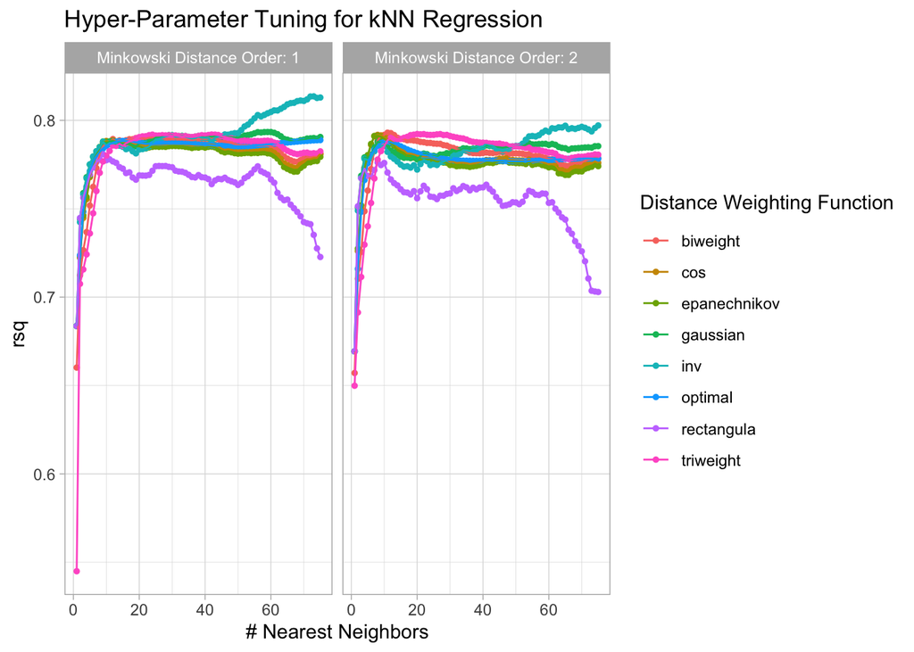

```r
doParallel::registerDoParallel()
set.seed(30)
knn_tune <- knn_flow %>%
  tune_grid(folds, grid = knn_grid, metrics = knn_metric)
autoplot(knn_tune) +
  theme_light() +
  labs(title="Hyper-Parameter Tuning for kNN Regression")
```

## Problem 2

> **What are the optimal values of the tuning parameters?**

```r
knn_best <- select_best(knn_tune)
knn_best
```

```
# A tibble: 1 × 4
  neighbors weight_func dist_power .config
      <int> <chr>            <int> <chr>
1        73 inv                  1 Preprocessor1_Model0673
```

The results suggest that we should use 73 neighbors, an inverse weight function, and use Manhattan distance.

## Problem 3

> **Re-fit the model for the optimal values of the tuning parameters. What is the predictive performance of the model in the test set?**

Performance in the test set is given by:

```r
knn_updated <- finalize_model(knn_spec, knn_best)
knn_flow2 <- knn_flow %>%
  update_model(knn_updated)
new_fit <- knn_flow2 %>%
  fit(data = train)
knn_test_metrics <- new_fit %>%
  predict(test) %>%
  bind_cols(test) %>%
  metrics(truth = happiness, estimate = .pred)
knn_test_metrics
```

```
# A tibble: 3 × 3
  .metric .estimator .estimate
  <chr>   <chr>          <dbl>
1 rmse    standard       0.990
2 rsq     standard       0.686
3 mae     standard       0.659
```

## References

Box, G. E. P., and D. R. Cox. 1964. “An Analysis of Transformations.” *Journal of the Royal Statistical Society. Series B (Methodological)* 26 (2): 211–52. http://www.jstor.org/stable/2984418.